# Categorical Data: Goodness of Fit Kolmogorov-Smirnov Test

Emily Brennan

## Palaeodiet Reconstruction in a Woman With Probable Celiac Disease: A Stable Isotope Analysis of Bone Remains From the Archaeological Site of Cosa (Italy)

We will use isotopic data from Scorrano et al. 2014 to investigate testing for Goodness of Fit, specifically using the Kolmogorov-Smirnov Test. The authors compared carbon and nitrogen isotope values in individuals across sexes and areas (historical periods) to test for potential dietary variablity.

First read in the isotopic analysis data from Scorrano et al. 2014

```r
isotopes <- read.csv("http://hompal-stats.wabarr.com/datasets/Scorrano_2014.csv", header=TRUE)
head(isotopes)
```

```
##        Sample    Species Sex   Age Percent.C Percent.N C.N  d13C d15N
## 1 Young woman H. sapiens   F 18-20      41.7      14.7 3.3 -19.5 10.7
## 2       Bu. 4 H. sapiens   I 14-18      41.9      15.4 3.2 -18.4  7.0
## 3       Bu. 6 H. sapiens   M 25-35      47.3      16.1 3.4 -17.8  9.3
## 4       Bu. 7 H. sapiens   M 25-35      40.5      14.5 3.2 -18.9  6.1
## 5      Bu. 13 H. sapiens   F 25-45      45.9      16.8 3.2 -18.2  9.9
## 6      Bu. 15 H. sapiens   I 13-20      42.2      15.3 3.2 -18.2  8.1
##   Percent.Collagen     Area
## 1              5.4
## 2              7.1 Forum II
## 3              9.1 Forum II
## 4              3.4 Forum II
## 5             10.4 Forum II
## 6              5.2 Forum II
```

## Filtering the data

Since we only care about certain values, we can filter the data first by sex:

```r
library(dplyr)
select.isotopes <- select(isotopes, Species, Sex, d13C, d15N, Area)
head(select.isotopes)
```

```
##      Species Sex  d13C d15N     Area
## 1 H. sapiens   F -19.5 10.7
## 2 H. sapiens   I -18.4  7.0 Forum II
## 3 H. sapiens   M -17.8  9.3 Forum II
## 4 H. sapiens   M -18.9  6.1 Forum II
## 5 H. sapiens   F -18.2  9.9 Forum II
## 6 H. sapiens   I -18.2  8.1 Forum II
```

```r
females <- filter(select.isotopes, Sex =="F", Area =="Forum II")
head(females)
```

```
##      Species Sex  d13C d15N     Area
## 1 H. sapiens   F -18.2  9.9 Forum II
## 2 H. sapiens   F -15.9  7.4 Forum II
## 3 H. sapiens   F -17.8  9.5 Forum II
## 4 H. sapiens   F -18.4  7.7 Forum II
## 5 H. sapiens   F -17.3  8.8 Forum II
## 6 H. sapiens   F -17.8  6.6 Forum II
```

```r
males <- filter(select.isotopes, Sex == "M", Area =="Forum II")
head(males)
```

```
##      Species Sex  d13C d15N     Area
## 1 H. sapiens   M -17.8  9.3 Forum II
## 2 H. sapiens   M -18.9  6.1 Forum II
## 3 H. sapiens   M -17.6  7.6 Forum II
## 4 H. sapiens   M -17.8  9.1 Forum II
## 5 H. sapiens   M -17.4  9.0 Forum II
## 6 H. sapiens   M -17.2  8.0 Forum II
```

And then by area:

```r
ForumII <- filter(select.isotopes, Species == "H. sapiens", Area == "Forum II")
head(ForumII)
```

```
##      Species Sex  d13C d15N     Area
## 1 H. sapiens   I -18.4  7.0 Forum II
## 2 H. sapiens   M -17.8  9.3 Forum II
## 3 H. sapiens   M -18.9  6.1 Forum II
## 4 H. sapiens   F -18.2  9.9 Forum II
## 5 H. sapiens   I -18.2  8.1 Forum II
## 6 H. sapiens   I -16.4  7.9 Forum II
```

```r
North <- filter(select.isotopes, Species == "H. sapiens", Area =="IX D North")
head(North)
```

```
##      Species Sex  d13C d15N       Area
## 1 H. sapiens   I -18.6  7.3 IX D North
## 2 H. sapiens   F -18.1  9.8 IX D North
## 3 H. sapiens   I -18.3  8.2 IX D North
## 4 H. sapiens   M -17.4 10.6 IX D North
```

## Performing the Goodness of Fit test

In the Kolmogorov-Smirnov test, D is the test statistic - the maximum difference between the observed and expected, and there is a corresponding p value.

First we run the test for the carbon and nitrogen isotopes by sex:

```r
ks.test(females$d13C, males$d13C)
```

```
##
##  Two-sample Kolmogorov-Smirnov test
##
## data:  females$d13C and males$d13C
## D = 0.3286, p-value = 0.5546
## alternative hypothesis: two-sided
```

```r
ks.test(females$d15N, males$d15N)
```

```
##
##  Two-sample Kolmogorov-Smirnov test
##
## data:  females$d15N and males$d15N
## D = 0.2143, p-value = 0.9516
## alternative hypothesis: two-sided
```

As you can see here, neither p value is significant, so the null hypothesis is not rejected. The comparison shows no significant difference in isotopic values between males and females from Forum II, indicating that there was no dietary difference between sexes.

Now run the test by area:

```r
ks.test(ForumII$d13C, North$d13C)
```

```
##
##  Two-sample Kolmogorov-Smirnov test
##
## data:  ForumII$d13C and North$d13C
## D = 0.4062, p-value = 0.6003
## alternative hypothesis: two-sided
```

```r
ks.test(ForumII$d15N, North$d15N)
```

[output not shown]

The p values here are not significant either and this comparison shows no significant difference in isotopic values between the individuals from different historic periods. This indicates that inhabitants of Cosa did not substantially change their dietary habits over centuries.

## Graphing the data

We can also replicate the graph from the paper to visualize the data:

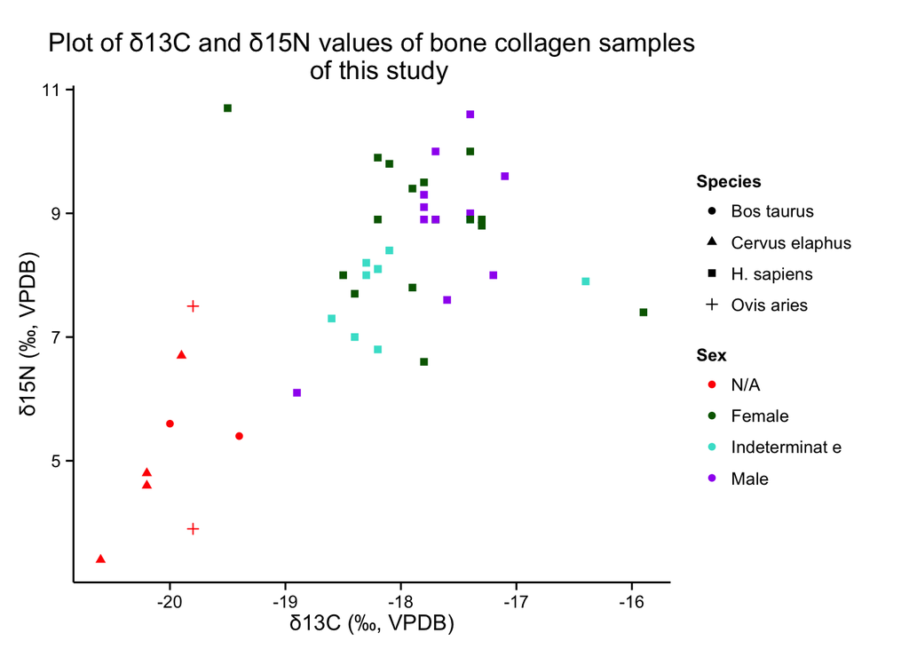

```r
library(ggplot2)
ggplot(data = isotopes, aes(x=d13C, y =d15N, group = Species, shape = Species, color = Sex)) +
  geom_point() +
  ylab("δ15N (‰, VPDB)") +
  xlab("δ13C (‰, VPDB)") +
  labs(title = "Plot of δ13C and δ15N values of bone collagen samples
  of this study") +
  scale_color_manual("Sex", labels = c("N/A", "Female", "Indeterminat e", "Male"), values = c("red", "dark green", "turquoise", "purple"))  +
  theme_classic()
```